# Final Project - An Analysis of Game of Throne’s Script

Colby Fry

2024-04-23

# Overview

The hit television show “Game of Thrones” is known for it’s incredibly rich story and beautifully portrayed world. However, neither of those two things would be complete, without the masterfully written ensemble of characters that make up George R.R. Martin’s fictional universe. A great story is only as great as those that are portrayed within that story. Between the Lannisters, Starks, Tyrells, Greyjoys, and the like, Game of Thrones is host to a sizable amount of characters and a whole lot to unpack between each. What is it exactly that makes the world of Westeros so riveting? Yes the setting, world-building, and cinematography are all top notch, but equally is that of the show’s script.

# Literature Review

## Preparatory Work

Before any analysis can be completed, the necessary tools to perform the analysis need to be loaded into the R Studio environment that this project was completed in.In addition, the script of the show needs to be imported into R Studio before any analysis can be possible.

```r
library(tidytext)
library(tidyverse)
library(gridExtra)
got_script <- read_csv("Game_of_Thrones_Script.csv")
```

## Pre-Processing

Next, the script cannot be analyzed as is. We need to perform some clean up before we can dive in and pick away at this file. The work performed, below, cleans up some of the variable names of the file and also removes common contractions from the Sentences variable of the file (script).

```r
got_script <- got_script %>%
  select('Release Date', 'Season', 'Episode Number' = Episode, 'Episode Title', Character = Name, Sentence)



fix.contractions <- function(doc) {
doc <- gsub("won't", "will not", doc)
doc <- gsub("can't", "can not", doc)
doc <- gsub("n't", " not", doc)
doc <- gsub("'ll", " will", doc)
doc <- gsub("'re", " are", doc)
doc <- gsub("'ve", " have", doc)
doc <- gsub("'m", " am", doc)
doc <- gsub("'d", " would", doc)
doc <- gsub("'s", "", doc)
return(doc)
}
got_script$Sentence <- sapply(got_script$Sentence, fix.contractions)
```

```r
tidy_script <- got_script %>%
unnest_tokens("word", Sentence)%>%
anti_join(stop_words)%>%
filter(nchar(word) > 2)
tidy_script$word <- gsub("\\s+","", tidy_script$word)
tidy_script$word <- gsub("[^a-zA-Z]","", tidy_script$word)
```

## Term Frequency Distriution

The following code begins our analysis of the most frequently spoken terms in the script of Game of Thrones, by Season. Starting off, we are creating a new object called “count_script”, which will simply count the number of words per season, sorted in descending order. The code below also creates a new object called “total_words”. This object is essentially creating a total of most common words in the script from the tidy_script object, the two objects are then left joined together. The “n” column of the season_words object is the number of times the word was spoken in a season and the “total” column is the number of words spoken in the season as a whole.

These results are then plotted as histograms, grouped by season, to showcase the distribution of word frequencies from the script.

```r
count_script <- tidy_script %>%
  count(Season, word, sort = TRUE)

total_words <- count_script %>%
  group_by(Season) %>%
  anti_join(stop_words)%>%
  filter(nchar(word) > 2) %>%
  summarise(total = sum(n))
season_words <- left_join(count_script, total_words)
season_words
```

```
## # A tibble: 23,664 × 4
##    Season   word       n total
##    <chr>    <chr>  <int> <int>
##  1 Season 1 lord     239 11626
##  2 Season 2 king     223 14260
##  3 Season 1 king     212 11626
##  4 Season 2 lord     205 14260
##  5 Season 3 lord     177 12631
##  6 Season 4 lord     154 12823
##  7 Season 4 king     150 12823
##  8 Season 3 king     140 12631
##  9 Season 5 king     134 11374
## 10 Season 1 father   126 11626
## # ℹ 23,654 more rows
```

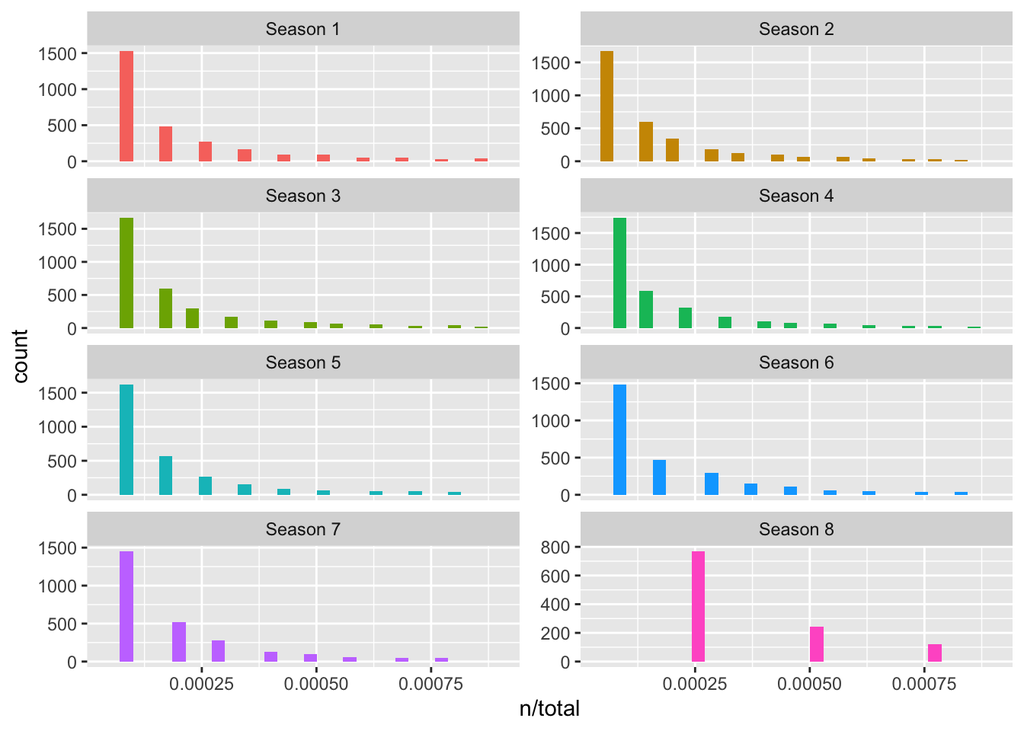

```r
#Term frequency distribution across each season of the show
ggplot(season_words, aes(n/total, fill = Season)) +
  geom_histogram(show.legend = FALSE) +
  xlim(NA, 0.0009) +
  facet_wrap(~Season, ncol = 2, scales = "free_y")
```

# Match Ratio

The tidytext package of R contains three general purpose lexicons for the purpose of evaluating moods, opinions, etc in a given text dataset. Those lexicons are “AFINN”, “bing”, and “nrc”. The three lexicons are based on unigrams (single words), with each word being assigned a certain value. In the case of the “nrc” lexicon for instance, each word may be given a specific emotion it would relate to, such as the word “frighten” giving off the emotion of “fear”.

Given that we have three lexicons we can work with, we should focus primarily on the lexicon that contains the most words from our dataset (script). We can determine this by calculating the match ratio between the Game of Thrones script and of the three lexicons, using the code below. Based on the match ratio results after running the following code, we can determine that the “nrc” lexicon has the most words in common with our dataset, compared to the other two lexicons.

```r
bing <- get_sentiments("bing")
nrc <- get_sentiments("nrc")
afinn <- get_sentiments("afinn")

afinn_neg_pos <- afinn %>%
mutate( sentiment = ifelse( value >= 0, "positive",
ifelse( value < 0,
"negative", value)))

afinn_neg_pos <-afinn_neg_pos %>%
select(word, sentiment)

sentiments <-bind_rows(list(bing=bing,nrc=nrc,afinn=afinn_neg_pos),.id =
"lexicon")
new_sentiments <- sentiments %>%
group_by(lexicon) %>%
mutate(words_in_lexicon = n_distinct(word)) %>%
ungroup()

new_sentiments <- sentiments %>%
group_by(lexicon) %>%
mutate(words_in_lexicon = n_distinct(word)) %>%
ungroup()

match_ratio_got <- tidy_script %>%
mutate(words_in_script = n_distinct(word)) %>%
inner_join(new_sentiments) %>%
group_by(lexicon,words_in_script, words_in_lexicon) %>%
summarise(lex_match_words = n_distinct(word)) %>%
ungroup() %>%
mutate(total_match_words = sum(lex_match_words),
match_ratio = lex_match_words / words_in_script) %>%
select(lexicon, lex_match_words, words_in_script, match_ratio)
match_ratio_got
```

```
## # A tibble: 3 × 4
##   lexicon lex_match_words words_in_script match_ratio
##   <chr>             <int>           <int>       <dbl>
## 1 afinn              1065            8799       0.121
## 2 bing               1638            8799       0.186
## 3 nrc                2113            8799       0.240
```

# Sentiment Analysis

Now that we have determined which lexicon we should proceed with, we can move forward in performing our sentiment analysis of the words in the Game of Thrones script, based around the “nrc” lexicon. To begin, we will perform an inner join on the sentiments from the “nrc” lexicon, to the list of words from our “tidy_script” object, storing the results in a new object called “got_nrc”.

```r
got_nrc <- tidy_script %>%
  inner_join(get_sentiments("nrc"))
head(got_nrc)
```

```
## # A tibble: 6 × 7
##   `Release Date` Season   `Episode Number` `Episode Title`  Character    word
##   <date>         <chr>    <chr>            <chr>            <chr>        <chr>
## 1 2011-04-17     Season 1 Episode 1        Winter is Coming waymar royce expect
## 2 2011-04-17     Season 1 Episode 1        Winter is Coming waymar royce expect
## 3 2011-04-17     Season 1 Episode 1        Winter is Coming waymar royce expect
## 4 2011-04-17     Season 1 Episode 1        Winter is Coming waymar royce expect
## 5 2011-04-17     Season 1 Episode 1        Winter is Coming royce        fright…
## 6 2011-04-17     Season 1 Episode 1        Winter is Coming royce        fright…
## # ℹ 1 more variable: sentiment <chr>
```

Now that we have paired each word from the Game of Thrones script with a corresponding emotion from the “nrc” lexicon, we can create a visualization of the most common words from the script and categorize them by the various emotions they give off. This visualization will not be categorized by Season, as the focus here is to gather a general idea on the script’s overall themes.

We can see that words from the script such as “kill”, “fight”, “war”, and the like all resonate with the emotion of “fear”. Depending on the context of the word’s usage within the script, you may notice the same word spread across multiple categories of emotions. The word “lord” is incredibly prevelant throughout the script in general, it should come as no surprise that depending on the context of its usage, the emotion it gives off varies. A character may express for a certain “lord” or exhbit the upmost respect for a certain “lord”, which leads to that word falling into the “positive” category.

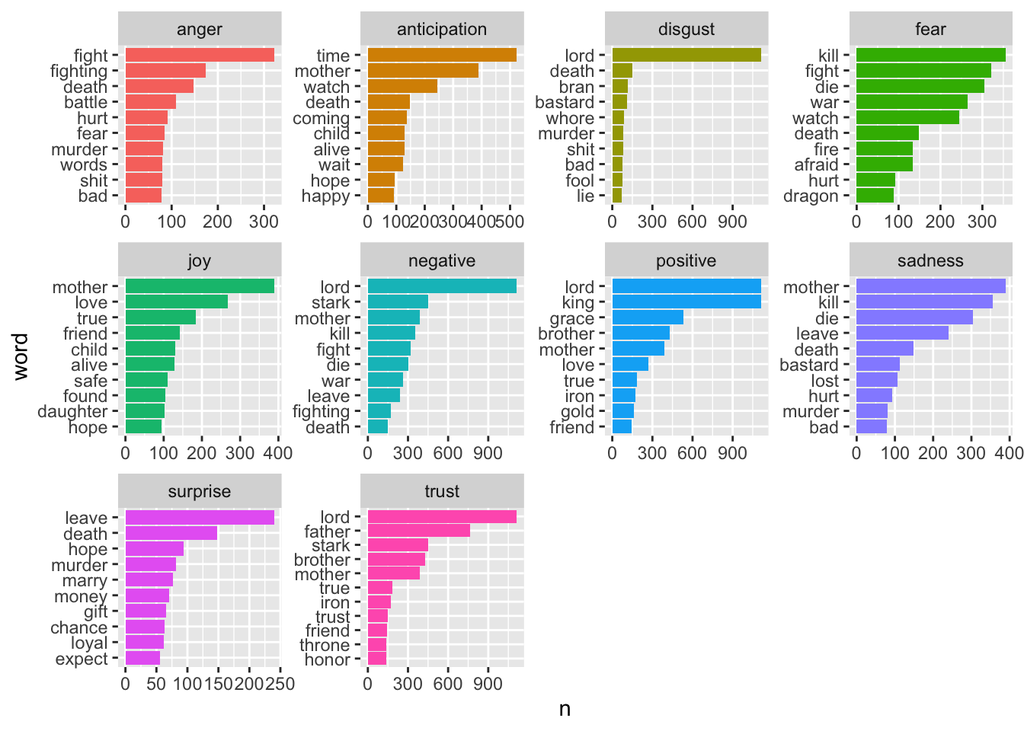

```r
tidy_script %>%
  inner_join(get_sentiments("nrc"))%>%
  count(word,sentiment,sort = TRUE)%>%
  group_by(sentiment)%>%
  top_n(10)%>%
  ungroup()%>%
  mutate(word=reorder (word,n))%>%
  ggplot(aes(word,n,fill=sentiment))+
  geom_col(show.legend = FALSE)+
  facet_wrap(~sentiment,ncol=,scales = "free")+
  coord_flip()
```

# Positivity and Polarity

Game of Thrones isn’t necessarily known for being all sunshine and rainbows, in fact, it’s rather bleak, aggressive, and even downright depressing at points. Of course, it isn’t like this the entirety of the show, there are pockets of happiness and positivty throughout its course. The next analysis dives a little further into the previous sentiment analysis where we focused on general sentiment across the script but this time around, putting a focus on each individual season and gathering insights on which seasons exhibited the most positivity. Based on the results below, we can see that seasons 8 and season 2 were the two most positive seasons. Perhaps due to season 2 still being very early on in the series and with season 8 being the final season, the light at the end of the tunnel can finally be viewed.

```r
got_sentiment_season <- got_nrc %>%
  group_by(Season) %>%
  mutate(Season_total = n()) %>%
  ungroup()

got_sentiment_season %>%
  count(Season, sentiment, Season_total) %>%
  mutate(percent = n / Season_total * 100) %>%
  filter(sentiment == "positive") %>%
  arrange(desc(percent))
```

```
## # A tibble: 8 × 5
##   Season   sentiment Season_total     n percent
##   <chr>    <chr>            <int> <int>   <dbl>
## 1 Season 8 positive          3005   648    21.6
## 2 Season 2 positive         11789  2482    21.1
## 3 Season 7 positive          6862  1437    20.9
## 4 Season 5 positive          9754  2036    20.9
## 5 Season 1 positive          9830  2009    20.4
## 6 Season 4 positive         10415  2120    20.4
## 7 Season 3 positive         10670  2167    20.3
## 8 Season 6 positive          8801  1686    19.2
```

While the “nrc” lexicon contained the most word matches when compared to the script, the “bing” lexicon is better suited for determining what words fall strictly into the “positive” and “negative” tonal categories. We can create what is called a “Word Cloud” to visualize the words in the script and whether they fall into the “positive” or “negative” category. The code below will only pull in 100 words, so we will be focusing on the top 100 words from the script that contribute to either of these two categories.

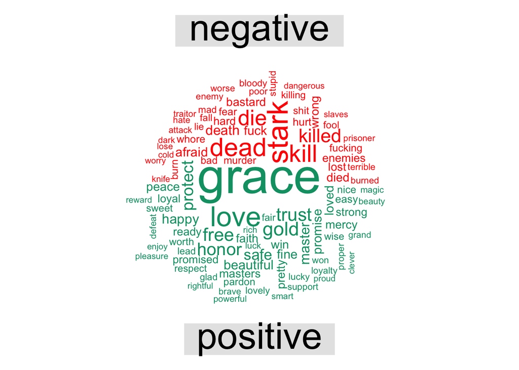

```r
library(wordcloud)
library(reshape2)
my_colors <- c("#E69F00", "#56B4E9", "#009E73", "#CC79A7", "#D55E00",
"#FF0000")

tidy_script %>%
inner_join(get_sentiments("bing")) %>%
count(word, sentiment, sort = TRUE) %>%
acast(word ~ sentiment, value.var = "n", fill = 0) %>%
comparison.cloud(colors=c(my_colors[6],my_colors[3]),max.words = 100)
```

```r
bigrams <- got_script %>%
  unnest_tokens(bigrams, Sentence, token = "ngrams", n = 2) %>%
  filter(!is.na(bigrams))
bigrams
```

```
## # A tibble: 273,513 × 6
##    `Release Date` Season   `Episode Number` `Episode Title`  Character   bigrams
##    <date>         <chr>    <chr>            <chr>            <chr>       <chr>
##  1 2011-04-17     Season 1 Episode 1        Winter is Coming waymar roy… what do
##  2 2011-04-17     Season 1 Episode 1        Winter is Coming waymar roy… do you
##  3 2011-04-17     Season 1 Episode 1        Winter is Coming waymar roy… you ex…
##  4 2011-04-17     Season 1 Episode 1        Winter is Coming waymar roy… expect…
##  5 2011-04-17     Season 1 Episode 1        Winter is Coming waymar roy… they a…
##  6 2011-04-17     Season 1 Episode 1        Winter is Coming waymar roy… are sa…
##  7 2011-04-17     Season 1 Episode 1        Winter is Coming waymar roy… savage…
##  8 2011-04-17     Season 1 Episode 1        Winter is Coming waymar roy… one lot
##  9 2011-04-17     Season 1 Episode 1        Winter is Coming waymar roy… lot st…
## 10 2011-04-17     Season 1 Episode 1        Winter is Coming waymar roy… steals…
## # ℹ 273,503 more rows
```

```r
bigrams_separated <- bigrams %>%
  separate(bigrams, c("word1", "word2"), sep = " ")


bigrams_filtered <- bigrams_separated %>%
  filter(!word1 %in% stop_words$word) %>%
  filter(!word2 %in% stop_words$word)

bigrams_filtered
```

```
## # A tibble: 18,453 × 7
##    `Release Date` Season  `Episode Number` `Episode Title` Character word1 word2
##    <date>         <chr>   <chr>            <chr>           <chr>     <chr> <chr>
##  1 2011-04-17     Season… Episode 1        Winter is Comi… waymar r… lot   stea…
##  2 2011-04-17     Season… Episode 1        Winter is Comi… royce     dead  frig…
##  3 2011-04-17     Season… Episode 1        Winter is Comi… royce     south run
##  4 2011-04-17     Season… Episode 1        Winter is Comi… royce     moved camp
##  5 2011-04-17     Season… Episode 1        Winter is Comi… jon snow  fath… watc…
##  6 2011-04-17     Season… Episode 1        Winter is Comi… eddard s… prac… bran
##  7 2011-04-17     Season… Episode 1        Winter is Comi… robb sta… bow   arm
##  8 2011-04-17     Season… Episode 1        Winter is Comi… jonrobb   quick bran
##  9 2011-04-17     Season… Episode 1        Winter is Comi… jonrobb   bran  fast…
## 10 2011-04-17     Season… Episode 1        Winter is Comi… cassel    lord  stark
## # ℹ 18,443 more rows
```

```r
bigram_counts <- bigrams_filtered %>%
  count(word1, word2, sort = TRUE)

bigram_counts
```

```
## # A tibble: 12,537 × 3
##    word1    word2         n
##    <chr>    <chr>     <int>
##  1 king     landing     194
##  2 jon      snow        127
##  3 night    watch       122
##  4 castle   black        91
##  5 lord     commander    84
##  6 ned      stark        71
##  7 iron     throne       63
##  8 casterly rock         57
##  9 lord     baelish      51
## 10 ser      davos        51
## # ℹ 12,527 more rows
```

```r
library(igraph)
bigram_graph <- bigram_counts %>%
    filter(n > 20) %>%
    graph_from_data_frame((directed = FALSE))

bigram_graph
```

```
## IGRAPH 8bdd855 UN-- 66 50 --
## + attr: name (v/c), n (e/n)
## + edges from 8bdd855 (vertex names):
##  [1] king    --landing   jon     --snow      night   --watch
##  [4] castle  --black     lord    --commander ned     --stark
##  [7] iron    --throne    casterly--rock      lord    --baelish
## [10] ser     --davos     robb    --stark     lady    --stark
## [13] lady    --sansa     lord    --stark     tywin   --lannister
## [16] iron    --islands   lord    --tyrion    king    --mad
## [19] white   --walkers   ser     --jaime     jaime   --lannister
## [22] stannis --baratheon ser     --loras     sansa   --stark
## + ... omitted several edges
```

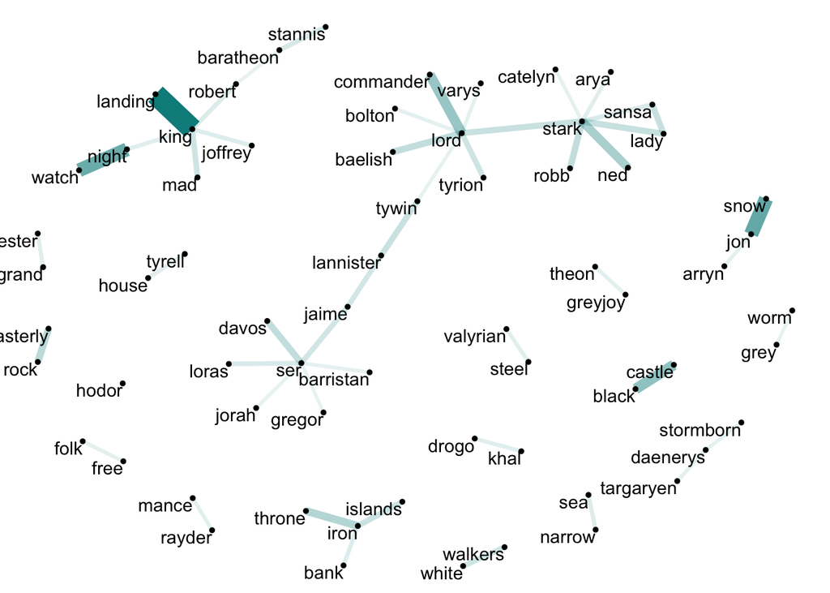

```r
library(ggraph)

set.seed(2017)

ggraph(bigram_graph, layout = "fr") +
  geom_edge_link(aes(edge_alpha = n, edge_width = n), show.legend = FALSE,edge_colour = "cyan4") +
  geom_node_point(size = 1) +
  geom_node_text(aes(label = name), vjust = 1, hjust = 1) +
  theme_void()
```

```r
pairwise_script <- got_script %>%
  unnest_tokens(word, Sentence, token = "words")
pairwise_script
```

```
## # A tibble: 297,424 × 6
##    `Release Date` Season   `Episode Number` `Episode Title`  Character    word
##    <date>         <chr>    <chr>            <chr>            <chr>        <chr>
##  1 2011-04-17     Season 1 Episode 1        Winter is Coming waymar royce what
##  2 2011-04-17     Season 1 Episode 1        Winter is Coming waymar royce do
##  3 2011-04-17     Season 1 Episode 1        Winter is Coming waymar royce you
##  4 2011-04-17     Season 1 Episode 1        Winter is Coming waymar royce expect
##  5 2011-04-17     Season 1 Episode 1        Winter is Coming waymar royce they
##  6 2011-04-17     Season 1 Episode 1        Winter is Coming waymar royce are
##  7 2011-04-17     Season 1 Episode 1        Winter is Coming waymar royce savag…
##  8 2011-04-17     Season 1 Episode 1        Winter is Coming waymar royce one
##  9 2011-04-17     Season 1 Episode 1        Winter is Coming waymar royce lot
## 10 2011-04-17     Season 1 Episode 1        Winter is Coming waymar royce steals
## # ℹ 297,414 more rows
```

```r
pairwise_filtered <- pairwise_script %>%
  anti_join(stop_words) %>%
  filter(nchar(word) >= 3)
pairwise_filtered$word <- gsub("\\s+","", pairwise_filtered$word)
pairwise_filtered$word <- gsub("[^a-zA-Z]","", pairwise_filtered$word)

pairwise_filtered
```

```
## # A tibble: 87,875 × 6
##    `Release Date` Season   `Episode Number` `Episode Title`  Character    word
##    <date>         <chr>    <chr>            <chr>            <chr>        <chr>
##  1 2011-04-17     Season 1 Episode 1        Winter is Coming waymar royce expect
##  2 2011-04-17     Season 1 Episode 1        Winter is Coming waymar royce savag…
##  3 2011-04-17     Season 1 Episode 1        Winter is Coming waymar royce lot
##  4 2011-04-17     Season 1 Episode 1        Winter is Coming waymar royce steals
##  5 2011-04-17     Season 1 Episode 1        Winter is Coming waymar royce goat
##  6 2011-04-17     Season 1 Episode 1        Winter is Coming waymar royce lot
##  7 2011-04-17     Season 1 Episode 1        Winter is Coming waymar royce rippi…
##  8 2011-04-17     Season 1 Episode 1        Winter is Coming waymar royce pieces
##  9 2011-04-17     Season 1 Episode 1        Winter is Coming will         wildl…
## 10 2011-04-17     Season 1 Episode 1        Winter is Coming will         life
## # ℹ 87,865 more rows
```

```r
pairwise_counts <- pairwise_filtered %>%
  count(word, sort = TRUE)

pairwise_counts
```

```
## # A tibble: 8,799 × 2
##    word        n
##    <chr>   <int>
##  1 lord     1112
##  2 king     1111
##  3 father    766
##  4 grace     534
##  5 time      523
##  6 lady      499
##  7 queen     476
##  8 stark     450
##  9 brother   431
## 10 north     421
## # ℹ 8,789 more rows
```

```r
library(widyr)

word_pairs <- pairwise_filtered %>%
  pairwise_count(word, Character, sort = TRUE)

word_pairs
```

```
## # A tibble: 18,436,340 × 3
##    item1  item2      n
##    <chr>  <chr>  <dbl>
##  1 king   lord     120
##  2 lord   king     120
##  3 lord   father   100
##  4 father lord     100
##  5 king   father    95
##  6 father king      95
##  7 time   lord      94
##  8 lord   time      94
##  9 night  lord      92
## 10 lord   night     92
## # ℹ 18,436,330 more rows
```

```r
# library(igraph)
# library(ggraph)
# library(dplyr)
#
# set.seed(2016)
#
# filtered_word_pairs <- word_pairs %>%
#   filter(n() >= 20)
#
# # Create graph
# graph <- graph_from_data_frame(filtered_word_pairs)
#
# # Plot graph
# ggraph(graph, layout = "fr") +
#   geom_edge_link(aes(edge_alpha = n), edge_colour = "cyan4", show.legend = FALSE) +
#   geom_node_point(size = 1) +
#   geom_node_text(aes(label = name), repel = TRUE) +
#   theme_void()
```